# Lab 5: Uncertainty, Samples, and Population

Ednita Tavarez-Jimenez

## Exponential Functions

**Q1: Show the R code you used to create exp_fun()**

```r
require(here)
here()
```

```
## [1] "/Users/ednitatavarez/Environmental Data/Environmental_Data"
```

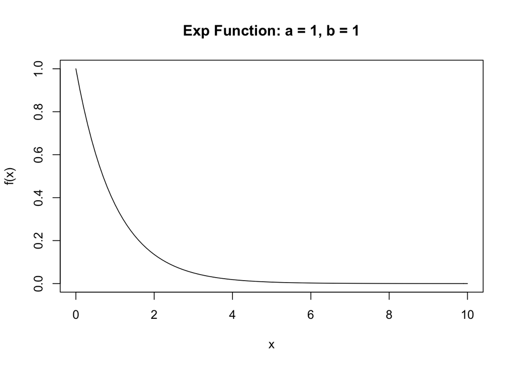

```r
dat_dis = read.csv(
  here("data", "dispersal.csv"))

ricker_fun = function(x, a, b)
{
  return(a * x * exp(-b * x))
}

exp_fun = function(x, a, b)

{
  return(a * exp(-b * x))
}
curve(
  exp_fun(x, 1, 1),
  from = 0, to = 10, add = FALSE,
  main = "Exp Function: a = 1, b = 1",
  ylab = "f(x)", xlab = "x")
```

**Q2: In your lab report, include a single figure containing four negative exponential curves with the following parameter values and line colors/textures:**

curve 1: a = 1.9, b = 0.1, line color = black, line texture = solid curve 2: a = 1.9, b = 0.3, line color = black, line texture = dotted curve 3: a = 1.2, b = 0.2, line color = red, line texture = solid curve 4: a = 1.2, b = 0.4, line color = red, line texture = dotted

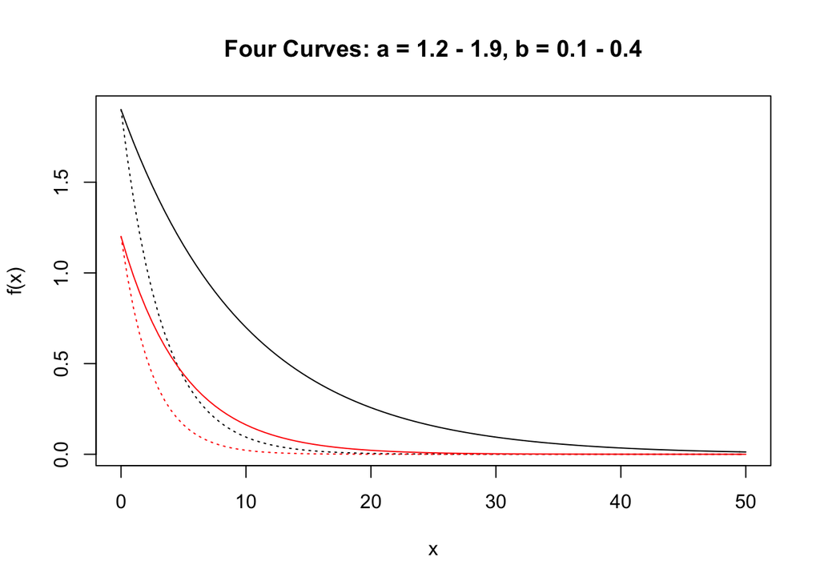

```r
exp_fun = function(x, a, b)

{
  return(a * exp(-b * x))
}
Curve_1 <- curve(exp_fun(x, 1.9, .1),
  from = 0, to = 50, add = FALSE,
  main = "Four Curves: a = 1.2 - 1.9, b = 0.1 - 0.4",
  ylab = "f(x)", xlab = "x",col = "black", lty = "solid" )

Curve_2 <- curve(exp_fun(x, 1.9, .3),
  from = 0, to = 50, add = TRUE,
  main = "",
  ylab = "f(x)", xlab = "x",col = "black", lty = "dotted" )

Curve_3 <- curve(exp_fun(x, 1.2, .2),
  from = 0, to = 50, add = TRUE,
  main = "Exp Function: a = 1.2, b = 0.2",
  ylab = "f(x)", xlab = "x",col = "red", lty = "solid" )

Curve_4 <- curve(exp_fun(x, 1.2, .4),
  from = 0, to = 50, add = TRUE,
  main = "Exp Function: a = 1.2, b = 0.4",
  ylab = "f(x)", xlab = "x",col = "red", lty = "dotted" )
```

**Q3: Observe how the curves vary as you change the two parameters’ values. Qualitatively describe what happens to the curve as you vary parameter a**

As you vary parameter a, the curve larger or smaller.

**Q4: Observe how the curves vary as you change the two parameters’ values. Qualitatively describe what happens to the curve as you vary parameter b**

As you vary parameter b, the curve gets bigger and smaller.

## Ricker Functions

**Q5 (6 pts.): In your lab report, include a single plot containing 6 Ricker curves with these parameter values:**

curve 1: a = 25, b = 0.2, line color = black, line texture = solid curve 2: a = 20, b = 0.2, line color = black, line texture = dotted curve 3: a = 10, b = 0.2, line color = black, line texture = dotted curve 4: a = 75, b = 0.3, line color = red, line texture = solid curve 5: a = 50, b = 0.3, line color = red, line texture = dotted curve 6: a = 40, b = 0.3, line color = red, line texture = dotted

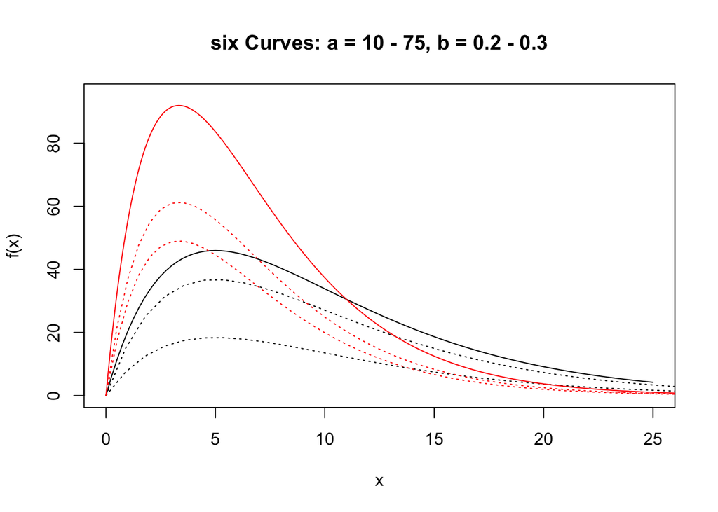

```r
ricker_fun = function(x, a, b)
{
  return(a * x * exp(-b * x))
}
Curve_1r <- curve(ricker_fun(x, 25, .2),
  from = 0, to = 25, add = FALSE,
  main = "six Curves: a = 10 - 75, b = 0.2 - 0.3", ylim = c(0,95),
  ylab = "f(x)", xlab = "x",col = "black", lty = "solid")

Curve_2r <- curve(ricker_fun(x, 20, .2),
  from = 0, to = 90, add = TRUE,
  ylab = "f(x)", xlab = "x",col = "black", lty = "dotted" )

Curve_3r <- curve(ricker_fun(x, 10, .2),
  from = 0, to = 90, add = TRUE,
  ylab = "f(x)", xlab = "x",col = "black", lty = "dotted" )

Curve_4r <- curve(ricker_fun(x, 75, .3),
  from = 0, to = 90, add = TRUE, n = 1000,
  ylab = "f(x)", xlab = "x",col = "red", lty = "solid" )

Curve_5r <- curve(ricker_fun(x, 50, .3),
  from = 0, to = 50, add = TRUE,
  ylab = "f(x)", xlab = "x",col = "red", lty = "dotted" )

curve_6r <- curve(ricker_fun(x, 40, .3),
  from = 0, to = 50, add = TRUE,
  ylab = "f(x)", xlab = "x",col = "red", lty = "dotted" )
```

**Q6 (2 pts.): Observe how the curves vary as you change the two parameters’ values. Qualitatively describe what happens to the curve as you vary parameter a**

**Q7 (2 pts.): Observe how the curves vary as you change the two** parameters’ values. Qualitatively describe what happens to the curve as you vary parameter b

## Salamander Models

**Q8: Linear Model. Provide the values of the slope, x1, and y1 parameters you chose. Briefly describe how you chose the values.**

I chose a = 0.07,and b = -0.00005, I chose based on where the points were and what I thought you be the better fit.

**Q9: In your lab report, include a scatterplot of the salamander data with your fitted linear model.**

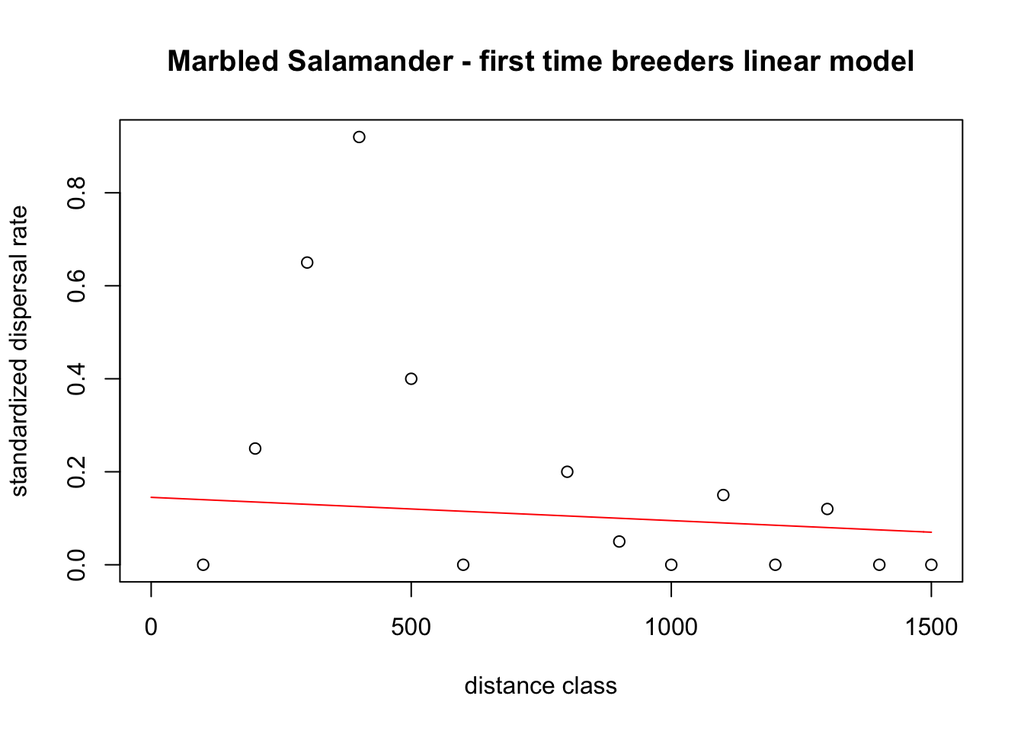

**Q10: Exponential Model. Provide the values of the a and b. Briefly describe how you chose the values.**

a = .9, b = 0.005)

**Q11: In your lab report, include a scatterplot of the salamander data with your fitted exponential model.**

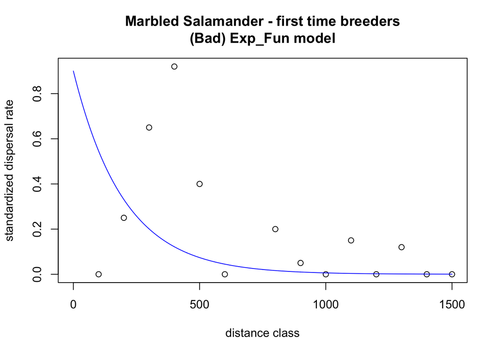

```r
line_point_slope = function(x, x1, y1, slope)
  {
    get_y_intercept =
      function(x1, y1, slope)
        return(-(x1 * slope) + y1)

    linear =
      function(x, yint, slope)
        return(yint + x * slope)

    return(linear(x, get_y_intercept(x1, y1, slope), slope))
}

exp_fun = function(x, a, b)

{
  return(a * exp(-b * x))
}

plot(
    dat_dis$dist.class,
    dat_dis$disp.rate.ftb,
    xlim = c(0, 1500),
    xlab = "distance class",
    ylab = "standardized dispersal rate",
    main = "Marbled Salamander - first time breeders\n(Bad) Exp_Fun model")
curve(exp_fun(x, .9, .005),
  from = 0, to = 1500, add = TRUE, n = 1000,
  ylab = "f(x)", xlab = "x",col = "blue", lty = "solid" )
```

```r
 exp_predicted <- line_point_slope(dat_dis$dist.class, 1500, .9, .005)
 Observed <- dat_dis$disp.rate.ftb
 resids_exp <- exp_predicted - Observed
```

**Q12: Ricker Model Provide the values of the a and b. Briefly describe how you chose the values.**

a = .005, b= 1/300

**Q13: In your lab report, include a scatterplot of the salamander data with your fitted ricker model.**

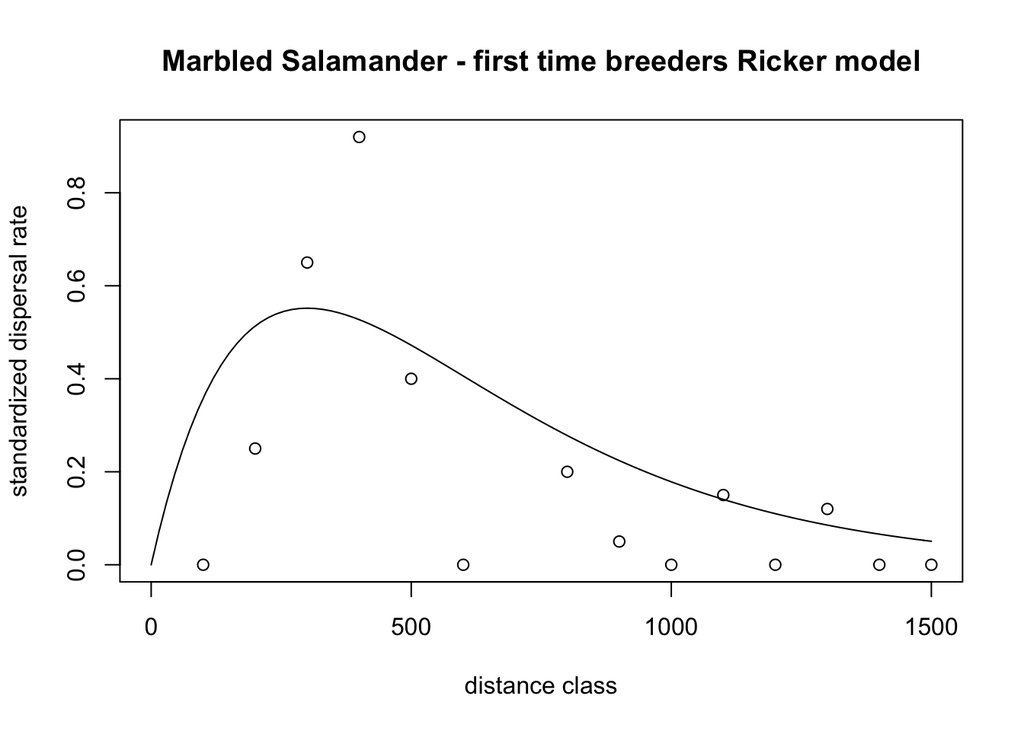

```r
line_point_slope = function(x, x1, y1, slope)
  {
    get_y_intercept =
      function(x1, y1, slope)
        return(-(x1 * slope) + y1)

    linear =
      function(x, yint, slope)
        return(yint + x * slope)

    return(linear(x, get_y_intercept(x1, y1, slope), slope))
}

ricker_fun = function(x, a, b)
{
  return(a * x * exp(-b * x))
}
plot(
    dat_dis$dist.class,
    dat_dis$disp.rate.ftb,
    xlim = c(0, 1500),
    xlab = "distance class",
    ylab = "standardized dispersal rate",
    main = "Marbled Salamander - first time breeders\ Ricker model")
curve(ricker_fun(x, .005, 1/300),
  from = 0, to = 1500, add = TRUE, ylim = c(0,1500),
  ylab = "f(x)", xlab = "x",col = "black", lty = "solid")
```

```r
 ricker_predicted <- line_point_slope(dat_dis$dist.class, 1500, .005, 1/300)
 Observed <- dat_dis$disp.rate.ftb
 resids_ricker <- exp_predicted - Observed
```

## Salamander Model Residuals

Calculate the residuals for your three fitted models and store them in a data.frame

The columns containing the residuals should have the following names: “resids_linear” “resids_exp” “resids_ricker”

**Q14 : Show the R code you used to create your data frame of model residuals.**

```r
 linear_predicted <- line_point_slope(dat_dis$dist.class, 1500, 0.07, -0.00005)
 Observed <- dat_dis$disp.rate.ftb
resids_linear <- linear_predicted - Observed

 exp_predicted <- line_point_slope(dat_dis$dist.class, 1500, .9, .005)
 Observed <- dat_dis$disp.rate.ftb
 resids_exp <- exp_predicted - Observed

ricker_predicted <- line_point_slope(dat_dis$dist.class, 1500, .005, 1/300)
 Observed <- dat_dis$disp.rate.ftb
 resids_ricker <- exp_predicted - Observed
```

**Q15 (3 pts.): In your lab report, include histograms of the residuals for each of your three models. You may create a single figure with three panels, or include three separate figures.**

For some readon the exp and ricker histograms look exactly the same.

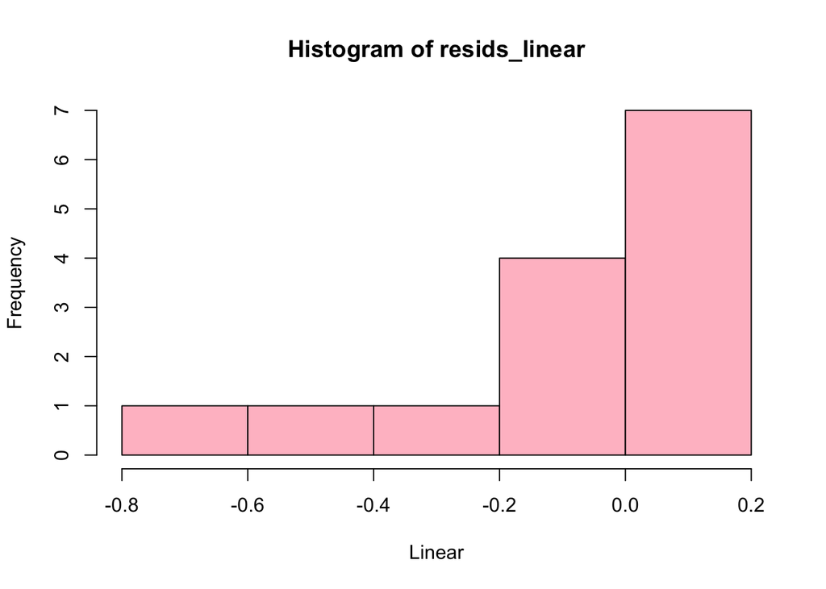

```r
hist(resids_linear, xlab = "Linear", col = "pink")
```

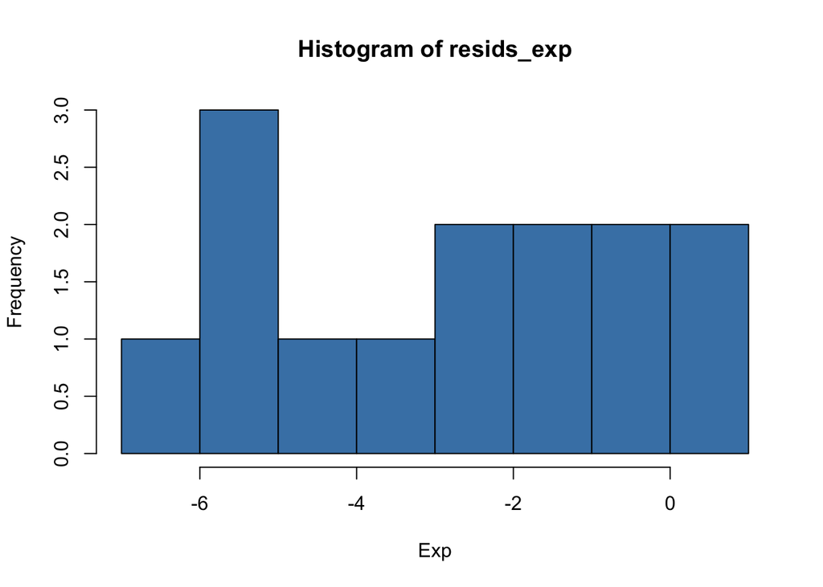

```r
hist(resids_exp, xlab = "Exp", col = "steel blue")
```

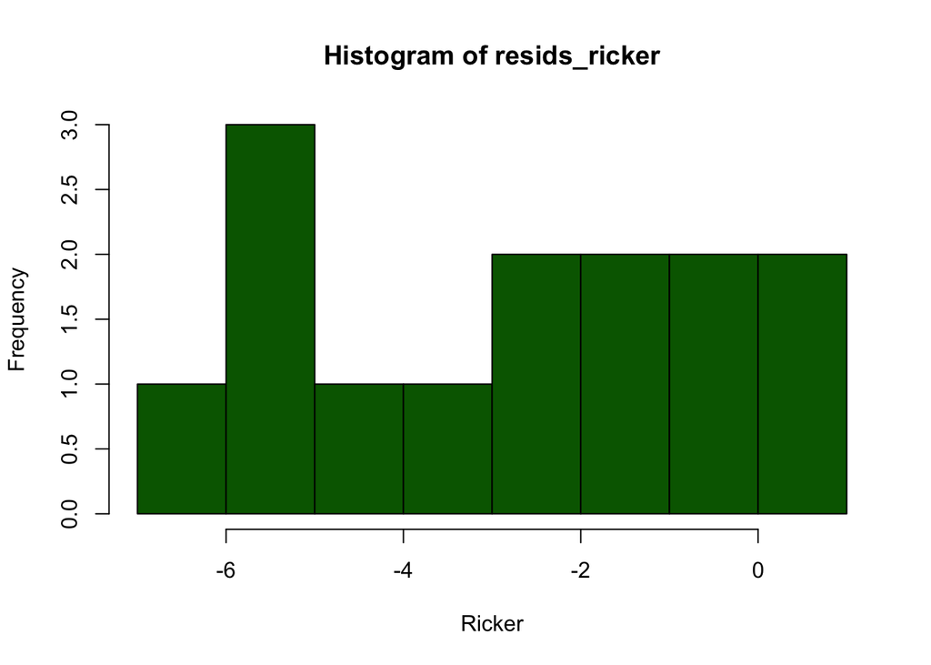

```r
hist(resids_ricker, xlab = "Ricker", col = " dark green")
```